# Introduction avancée à Matplotlib

## Graphiques interactifs et axes 3D

> Lors des exercices précédents, les différents graphiques étaient affichés dans la page grâce à la commande:

```
%matplotlib inline
```

> Il est possible d'obtenir des graphiques avec quelques outils interactifs supplémentaires en remplaçant cette dernière par la commande:

```
%matplotlib notebook
```

> Les graphiques ainsi affichés disposent des outils suivants: Déplacer, zoomer, obtenir les valeurs des points sur lesquelles le curseur est placé ou encore enregistrer l'image à l'état actuel.

> Exécuter la cellule suivante pour afficher un exemple de graphique et avoir un aperçu des outils disponibles.

```python
import warnings
warnings.filterwarnings("ignore")

import matplotlib.pyplot as plt
import numpy as np
%matplotlib notebook
```

[figure not shown]

> Sur `Matplotlib` il est également possible d'afficher des graphiques en trois dimensions, grâce à l'import du package **`Axes3D`** et à l'ajout de l'argument `projection='3d'` lors de la création des Axes.  
> Les méthodes de création graphique élémentaires, comme celles permettant de tracer des courbes ou des nuages de points, peuvent ensuite prendre en argument une dimension supplémentaire.  
> En plus des outils interactifs, les graphiques ainsi crées peuvent être déplacés sur trois dimensions.

### Courbes 3D

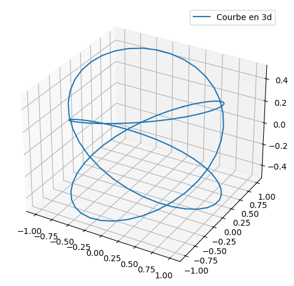

```python
## Insérez votre code ici
```

### Nuages de points 3D

- Créer le vecteur **z** de 100 points répartis entre 0 et 1
- Créer les vecteurs **x**$= z \times sin(20z)$ et **y** $= z \times cos(20z)$
- Afficher un nuage de points en trois dimensions à partir de x,y,z et ajouter les **labels** correspondants à chacun des axes

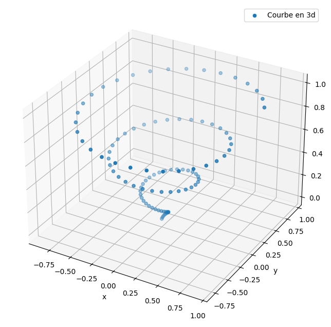

```python
## Insérez votre code ici
```

### Barplots 3D

> La méthode `bar3d` permet d'afficher des graphiques en barres en 3 dimensions. Pour ce faire, elle reçoit en argument les coordonnées de position des barres, ainsi que la taille des barres sur chaque axe qui correspondent respectivement à la largeur, la profondeur et la hauteur des barres.  
> Exemple :

```
ax = fig.add_subplot(111, projection='3d')
ax.bar3d(xpos, ypos, bottom, width, depth, top)
```

Sauf dans le cas de barres empilées, les coordonnées de position du troisième sont souvent nulles.

- Créer le vecteur **x** contenant la séquence d'entier entre 1 et 10.
- Créer le vecteur **y** : [2,3,4,5,1,6,2,1,7,2]
- Créer le vecteur **z**, nul de taille 10
- Créez les vecteurs **dx** et **dy** contenant le nombre 1 répété 10 fois, et le vecteur **dz** = [1,2,3,4,5,6,7,8,9,10]
- Affichez un barplot 3D de couleur `#14c989` à partir des positions **x**,**y** et **z** et des tailles de barre **dx**,**dy**,**dz**

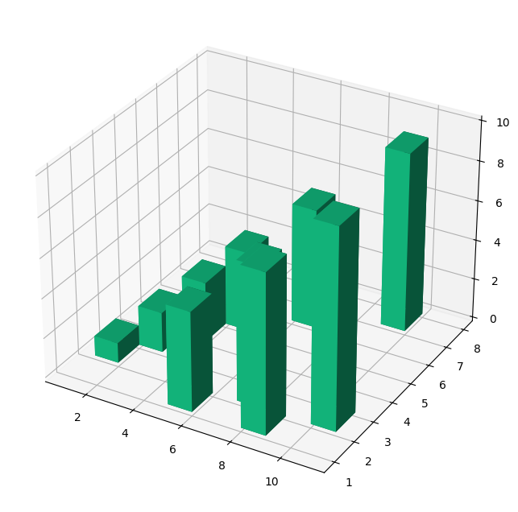

```python
## Insérez votre code ici
```

### Wireframes

> Un *Wireframe* est une forme à trois dimensions composée uniquement de "câbles" (lignes et sommets) )et ne possédant pas de surfaces ou de textures.  
> Les *Wireframes* prennent une grille de valeurs et la projettent sur la surface tri-dimensionnelle pour un rendu facile à visualiser.

> La méthode **`plot_wireframe`** permet d'afficher des *wireframes*, à partir de trois grilles de coordonnées à 2 dimensions.
- Créer le vecteur **u** contenant la séquence de 30 nombres entre 0 et $\pi$
- Créer le vecteur **v** contenant la séquence de 30 nombres entre 0 et $2\pi$
- Créer le tableau **x** contenant le produit matriciel $sin(u) (sin(v)^T)$ grâce à la fonction **`outer`** de *numpy*
- Créer le tableau **y** contenant le produit matriciel $sin(u) (cos(v)^T)$ grâce à la fonction **`outer`** de *numpy*
- Créer le tableau **z** contenant le produit matriciel $cos(u) (\mathbb1_{30})^T $ où $\mathbb1_{30}$ représente un vecteur de taille 30 rempli de 1
- Afficher le *wireframe* obtenu grâce à **x**,**y**,**z**

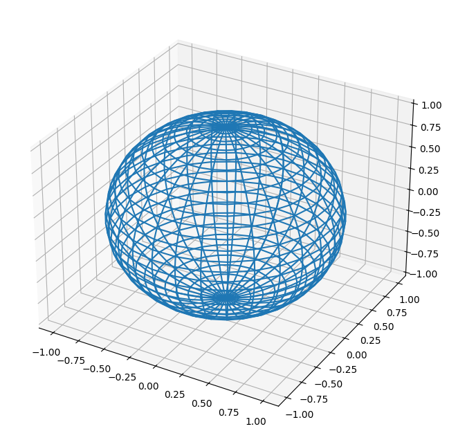

```python
## Insérez votre code ici
# help(np.outer)
```

### Surface plots

> Les graphiques de surface sont parfois utiles pour aider à visualiser des fonctions complexes et leurs contours en 3D. La méthode **`plot_surface`** permet d'ajouter une représentation 3D de la surface d'une fonction, colorée en fonction de ses niveaux.
- Créer la matrice **x** défini par le produit matriciel suivant: `np.outer(np.linspace(-2, 2, 30), np.ones(30))`
- Créer **y**, la transposée de **x**
- Créer **z** comme la fonction : $ z = \cos(x^2 + y^2)$
- Afficher un *surface plot* à partir de **x**, **y** et **z**, en ajoutant l'argument `cmap=plt.cm.Spectral_r` pour personnaliser les couleurs utilisées

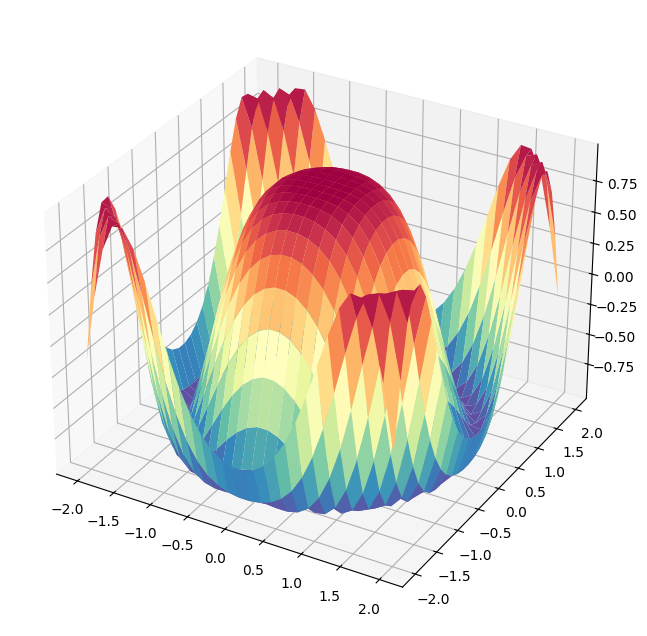

```python
## Insérez votre code ici
```